# Qualitative Activity Recognition of Weight Lifting Exercises

Mariano Fiorentino

07/07/2016

# Executive Summary

Using devices such as Jawbone Up, Nike FuelBand, and Fitbit it is now possible to collect a large amount of data about personal activity relatively inexpensively. These type of devices are part of the quantified self movement – a group of enthusiasts who take measurements about themselves regularly to improve their health, to find patterns in their behavior, or because they are tech geeks. In this project the goal is to use data from accelerometers on the belt, forearm, arm, and dumbell of 6 participants to predict the manner in which they did the exercises.

### Esploration of the dataset

The data for this project come from this source: http://groupware.les.inf.puc-rio.br/har. We got the training data for this project here:

https://d396qusza40orc.cloudfront.net/predmachlearn/pml-training.csv

And the test data from here:

https://d396qusza40orc.cloudfront.net/predmachlearn/pml-testing.csv

```r
set.seed(1234)
if (!"pml-training.csv"  %in% dir()) {
    download.file("https://d396qusza40orc.cloudfront.net/predmachlearn/pml-training.csv",
        destfile = "pml-training.csv", method = "curl")
}
#Remove NAs and null values
dataSet <- read.csv("pml-training.csv", na.strings=c("NA","NaN", "", " "))
dataSet <- dataSet[, colSums(is.na(dataSet)) == 0]
#Remove name and dates
dataSet <- dataSet[, -c(1:5)]
#matrix(data = names(dataSet), ncol = 5)
```

To explore the variability and patterns in the dataset we did an svd analisys. As expected the plot shown a significant pattern on the row side, and a minor one on the column side:

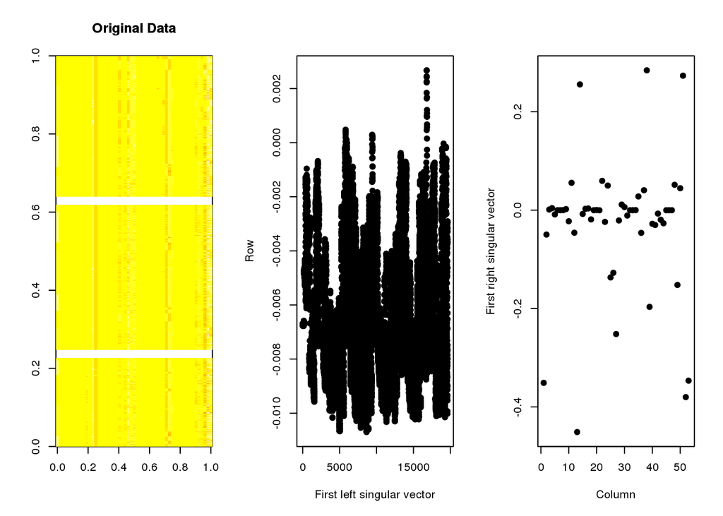

```r
matrixForSdv <- as.matrix(dataSet[,-c(1,55)])
svd1 <- svd(matrixForSdv)
par(mfrow = c(1, 3))
image(t(matrixForSdv)[, nrow(matrixForSdv):1], main = "Original Data")
plot(svd1$u[, 1], ylab = "Row", xlab = "First left singular vector",pch = 19)
plot(svd1$v[, 1], xlab = "Column", ylab = "First right singular vector", pch = 19)
```

### Study design with cross validation

To find the best model to predict the manner in which partecipant did the excercise we splited the dataset in 3 parts:

- the training set (50%), used to build the model
- the test set (25%), used to test the model
- the validation set (25%), used at the end only one time on the choosed model

```r
inTrain = createDataPartition(dataSet$classe, p = 1/2)[[1]]

training = dataSet[ inTrain,]
testingToSplit = dataSet[-inTrain,]

inTest = createDataPartition(testingToSplit$classe, p = 1/2)[[1]]

testing = testingToSplit[ inTest,]
validation = testingToSplit[-inTest,]
```

### Building the model

We buildt 3 different model:

- **Random Forest**

```r
fitControl <- trainControl(method = "cv",
                           number = 3,
                           allowParallel = TRUE)
x <- training[,-55]
y <- training[,55]

mod1 <- train(x, y, method = "rf", data = training, trControl = fitControl)
pred1 <- predict(mod1, testing[,!names(testing) == 'classe'])
conf1 <- confusionMatrix(pred1, testing$classe)
conf1$table
```

```
##           Reference
## Prediction    A    B    C    D    E
##          A 1395    2    0    0    0
##          B    0  944    2    0    0
##          C    0    2  854    4    0
##          D    0    1    0  800    4
##          E    0    0    0    0  898
```

- **Recursive partitioning**

```r
mod2 <- train(classe~., method = "rpart", data = training)
pred2 <- predict(mod2, testing[,!names(testing) == 'classe'])
conf2 <- confusionMatrix(pred2, testing$classe)
conf2$table
```

```
##           Reference
## Prediction    A    B    C    D    E
##          A 1252  403  396  351  123
##          B   30  315   24  152  123
##          C  111  231  436  301  244
##          D    0    0    0    0    0
##          E    2    0    0    0  412
```

- **Linear discriminant analysis**

```r
mod3 <- train(classe~., method = "lda", data = training)
pred3 <- predict(mod3, testing[,!names(testing) == 'classe'])
conf3 <- confusionMatrix(pred3, testing$classe)
conf3$table
```

```
##           Reference
## Prediction    A    B    C    D    E
##          A 1132  133   78   36   32
##          B   38  629   74   38  130
##          C  104  111  585   92   86
##          D  117   32  100  608   84
##          E    4   44   19   30  570
```

**We choosed the model based on Random Forest because showed the best accuracy rate**

```r
data.frame("Random Forest" = conf1$overall[1], "Recursive Partitioning" = conf3$overall[1], "Linear Discriminant Analisys" = conf3$overall[1])
```

[output not shown]

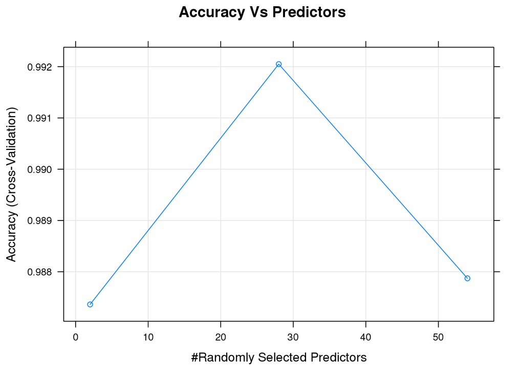

```r
plot(mod1, log="y", main="Accuracy Vs Predictors")
```

```r
predFinal <- predict(mod1, validation[,!names(validation) == 'classe'])
confFinal <- confusionMatrix(predFinal, validation$classe)
confFinal$table
```

```
##           Reference
## Prediction    A    B    C    D    E
##          A 1395    3    0    0    0
##          B    0  943    4    0    0
##          C    0    1  851   10    0
##          D    0    2    0  794    0
##          E    0    0    0    0  901
```

```r
data.frame("In Sample Error" = (sum(conf1$table) - sum(diag(conf1$table)))/sum(diag(conf1$table)),
           "Out Of Sample Error" = (sum(confFinal$table) - sum(diag(confFinal$table)))/sum(diag(confFinal$table)))
```

```
##   In.Sample.Error Out.Of.Sample.Error
## 1     0.003066857         0.004095004
```

### Predicting on the 20 test cases

To predict the 20 test cases we did on the dataset the same trasformation that we did on the training set.

```r
if (!"pml-testing.csv"  %in% dir()) {
    download.file("https://d396qusza40orc.cloudfront.net/predmachlearn/pml-testing.csv",
        destfile = "pml-testing.csv", method = "curl")
}
testCases <- read.csv("pml-testing.csv", na.strings=c("NA","NaN", "", " "))
testCases <- testCases[, colSums(is.na(testCases)) == 0]
testCases <- testCases[, -c(1:5)]
testCases <- testCases[, -c(55)]
levels(testCases$new_window) <- levels(training$new_window)
data.frame(predict(mod1, testCases))
```

```
##    predict.mod1..testCases.
## 1                         B
## 2                         A
## 3                         B
## 4                         A
## 5                         A
## 6                         E
## 7                         D
## 8                         B
## 9                         A
## 10                        A
## 11                        B
## 12                        C
## 13                        B
## 14                        A
## 15                        E
## 16                        E
## 17                        A
## 18                        B
## 19                        B
## 20                        B
```